# **Assignment 9**

In this assignment, you will use R (within R-Studio) to:

- Load and clean a real data set
- Conduct exploratory analyses, including informative figures
- Build and test appropriate models
- Draw conclusions about your data
- Combine all of the above into a well-documented R-Markdown report and export (knit) it into an HTML file

**All file paths should be relative, starting from *your* Assignment_9 directory!!**

**This means that you need to create a new R-Project named “Assignment_9.Rproj” in your Assignment_9 directory, and work from scripts within that.**

## **For credit…**

1. Push a completed version of your Rproj and R-markdown file (details at end of this assignment) to GitHub
2. Your score will also depend on your analyses and presentation of your final report

# Your tasks:

- Use the data set “/Data/GradSchool_Admissions.csv”
- You will explore and model the predictors of graduate school admission
  - the “admit” column is coded as 1=success and 0=failure (that’s binary, so model appropriately)
  - the other columns are the GRE score, the GPA, and the rank of the undergraduate institution, where I is “top-tier.”
- Document your data explorations, figures, and conclusions in a reproducible R-markdown report
- That means I want to see, in your html report, your process of model evaluation and selection. Here’s an [example](https://gzahn.github.io/data-course/Repository/Assignments/Assignment_9/example.html)
- Upload your **self-contained** R project, including knitted HTML report, to GitHub in *your* Assignment_9 directory

# Analysis

## Data Loading and Cleaning

```r
# Load
library(tidyverse)

# Read .csv
df <- read.csv("./Data/GradSchool_Admissions.csv")

# Convert admit and rank into factors
df$admit <- as.factor(df$admit)
df$rank <- as.factor(df$rank)

summary(df)
```

```
##  admit        gre             gpa        rank
##  0:273   Min.   :220.0   Min.   :2.260   1: 61
##  1:127   1st Qu.:520.0   1st Qu.:3.130   2:151
##          Median :580.0   Median :3.395   3:121
##          Mean   :587.7   Mean   :3.390   4: 67
##          3rd Qu.:660.0   3rd Qu.:3.670
##          Max.   :800.0   Max.   :4.000
```

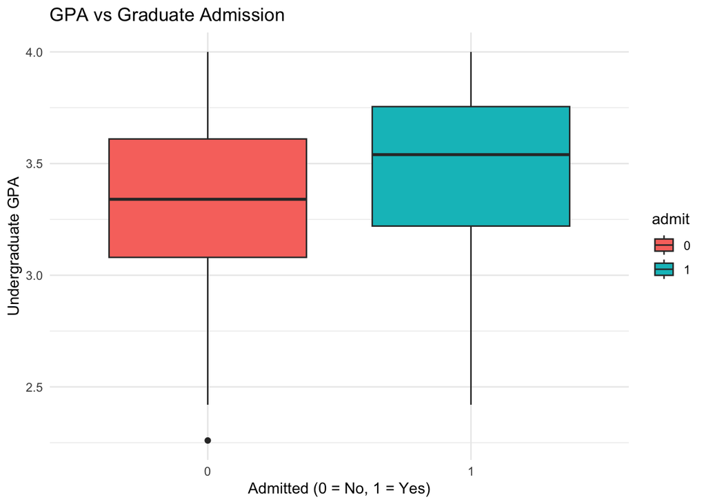

```r
ggplot(df, aes(x = admit, y = gpa, fill = admit)) +
  geom_boxplot() +
  theme_minimal() +
  labs(title = "GPA vs Graduate Admission",
       x = "Admitted (0 = No, 1 = Yes)",
       y = "Undergraduate GPA")
```

## More Exploring

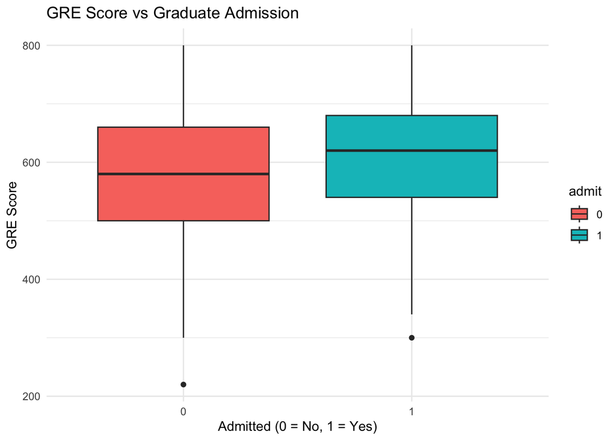

```r
# GRE score vs admission
ggplot(df, aes(x = admit, y = gre, fill = admit)) +
  geom_boxplot() +
  theme_minimal() +
  labs(title = "GRE Score vs Graduate Admission",
       x = "Admitted (0 = No, 1 = Yes)",
       y = "GRE Score")
```

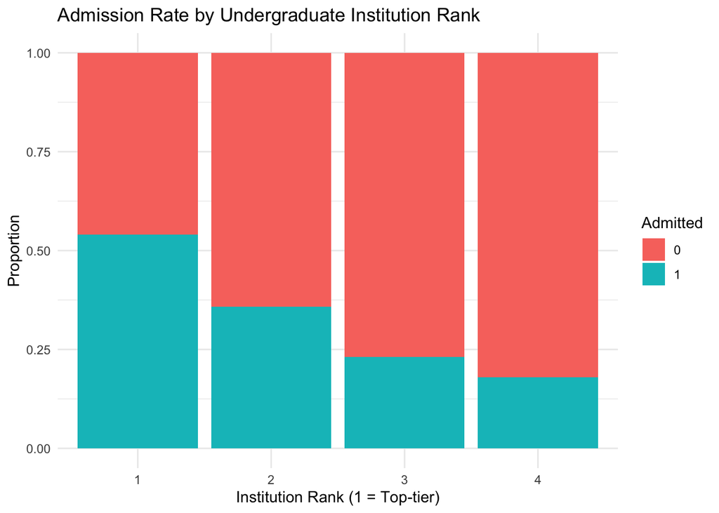

```r
# Admission rate by institution rank
ggplot(df, aes(x = rank, fill = admit)) +
  geom_bar(position = "fill") +
  theme_minimal() +
  labs(title = "Admission Rate by Undergraduate Institution Rank",
       x = "Institution Rank (1 = Top-tier)",
       y = "Proportion",
       fill = "Admitted")
```

## Model Building

```r
model_full <- glm(admit ~ gre + gpa + rank,
                  data = df,
                  family = binomial)
summary(model_full)
```

```
##
## Call:
## glm(formula = admit ~ gre + gpa + rank, family = binomial, data = df)
##
## Coefficients:
##              Estimate Std. Error z value Pr(>|z|)
## (Intercept) -3.989979   1.139951  -3.500 0.000465 ***
## gre          0.002264   0.001094   2.070 0.038465 *
## gpa          0.804038   0.331819   2.423 0.015388 *
## rank2       -0.675443   0.316490  -2.134 0.032829 *
## rank3       -1.340204   0.345306  -3.881 0.000104 ***
## rank4       -1.551464   0.417832  -3.713 0.000205 ***
## ---
## Signif. codes:  0 '***' 0.001 '**' 0.01 '*' 0.05 '.' 0.1 ' ' 1
##
## (Dispersion parameter for binomial family taken to be 1)
##
##     Null deviance: 499.98  on 399  degrees of freedom
## Residual deviance: 458.52  on 394  degrees of freedom
## AIC: 470.52
##
## Number of Fisher Scoring iterations: 4
```

## Model Comparison and Selection

```r
# Reduced models to compare against full model
model_no_gre <- glm(admit ~ gpa + rank, data = df, family = binomial)
model_no_gpa <- glm(admit ~ gre + rank, data = df, family = binomial)
model_rank_only <- glm(admit ~ rank, data = df, family = binomial)

# Compare using AIC
AIC(model_full, model_no_gre, model_no_gpa, model_rank_only)
```

```
##                 df      AIC
## model_full       6 470.5175
## model_no_gre     5 472.8753
## model_no_gpa     5 474.5318
## model_rank_only  4 482.9667
```

```r
# Compare using likelihood ratio test
anova(model_rank_only, model_no_gre, model_full, test = "Chisq")
```

```
## Analysis of Deviance Table
##
## Model 1: admit ~ rank
## Model 2: admit ~ gpa + rank
## Model 3: admit ~ gre + gpa + rank
##   Resid. Df Resid. Dev Df Deviance  Pr(>Chi)
## 1       396     474.97
## 2       395     462.88  1  12.0915 0.0005065 ***
## 3       394     458.52  1   4.3578 0.0368407 *
## ---
## Signif. codes:  0 '***' 0.001 '**' 0.01 '*' 0.05 '.' 0.1 ' ' 1
```

```r
# Assign best model
best_model <- model_full
summary(best_model)
```

```
##
## Call:
## glm(formula = admit ~ gre + gpa + rank, family = binomial, data = df)
##
## Coefficients:
##              Estimate Std. Error z value Pr(>|z|)
## (Intercept) -3.989979   1.139951  -3.500 0.000465 ***
## gre          0.002264   0.001094   2.070 0.038465 *
## gpa          0.804038   0.331819   2.423 0.015388 *
## rank2       -0.675443   0.316490  -2.134 0.032829 *
## rank3       -1.340204   0.345306  -3.881 0.000104 ***
## rank4       -1.551464   0.417832  -3.713 0.000205 ***
## ---
## Signif. codes:  0 '***' 0.001 '**' 0.01 '*' 0.05 '.' 0.1 ' ' 1
##
## (Dispersion parameter for binomial family taken to be 1)
##
##     Null deviance: 499.98  on 399  degrees of freedom
## Residual deviance: 458.52  on 394  degrees of freedom
## AIC: 470.52
##
## Number of Fisher Scoring iterations: 4
```

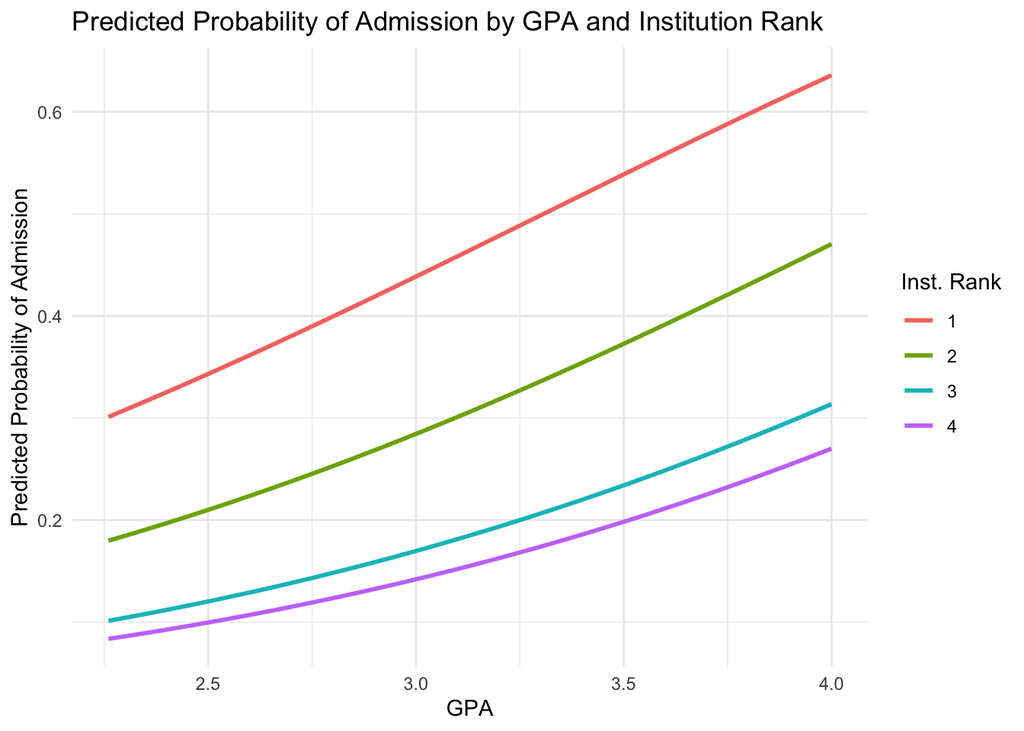

```r
# Predicted probability of admission across GPA, split by rank
new_data <- expand.grid(
  gpa  = seq(min(df$gpa), max(df$gpa), length.out = 100),
  gre  = mean(df$gre),
  rank = levels(df$rank)
)

new_data$predicted <- predict(best_model, newdata = new_data, type = "response")

ggplot(new_data, aes(x = gpa, y = predicted, color = rank)) +
  geom_line(linewidth = 1) +
  theme_minimal() +
  labs(title = "Predicted Probability of Admission by GPA and Institution Rank",
       x = "GPA",
       y = "Predicted Probability of Admission",
       color = "Inst. Rank")
```

## Conclusions

- If all other variables are constant, increasing your GPA by one unit/ point increases your odds of admission to grad school by about 2.23 times.

```r
# Summary of admission rates
df %>%
  group_by(rank, admit) %>%
  summarise(n = n(), .groups = "drop") %>%
  pivot_wider(names_from = admit, values_from = n, names_prefix = "admit_") %>%
  mutate(admission_rate = admit_1 / (admit_0 + admit_1))
```

```
## # A tibble: 4 × 4
##   rank  admit_0 admit_1 admission_rate
##   <fct>   <int>   <int>          <dbl>
## 1 1          28      33          0.541
## 2 2          97      54          0.358
## 3 3          93      28          0.231
## 4 4          55      12          0.179
```

```r
# Odds ratios with confidence intervals
exp(coef(best_model))
```

```
## (Intercept)         gre         gpa       rank2       rank3       rank4
##   0.0185001   1.0022670   2.2345448   0.5089310   0.2617923   0.2119375
```

```r
exp(confint(best_model))
```

```
##                   2.5 %    97.5 %
## (Intercept) 0.001889165 0.1665354
## gre         1.000137602 1.0044457
## gpa         1.173858216 4.3238349
## rank2       0.272289674 0.9448343
## rank3       0.131641717 0.5115181
## rank4       0.090715546 0.4706961
```